# icare

[figure not shown]

**I**ntelligent **C**linl**A**bomics **R**esearch **E**xpedition

A modular R framework that takes clinical / omics data all the way from raw table to publication-ready figures: statistics and missing-data handling, feature selection, machine-learning benchmarking, unsupervised subtyping (K-means, NMF, latent profile analysis), and prognostic / survival modeling — each with an interactive Shiny deployment layer.

[figure not shown]

**Maintainer:** Huaichao Luo (luohc@uestc.edu.cn) — [Google Scholar](https://scholar.google.com/citations?user=XNKOGaIAAAAJ) | [ResearchGate](https://www.researchgate.net/profile/Huaichao-Luo) | [Lab Twitter/X](https://x.com/Luo_lab)

**Contributor:** Guangchuang Yu — [Lab website (yulab-smu.top)](https://yulab-smu.top)

📖 **Full tutorial & documentation:** **[yulab-smu.top/icare](https://yulab-smu.top/icare/)**

## Contents

- Overview
- See icare in action
- Installation
- The four modules
- Essential Commands
  - Module 1 — Data cleaning (`Stat`)
  - Module 2 — Modeling (`Train_Model`)
  - Module 3 — Subtyping (`Subtyping`)
  - Module 4 — Survival / Prognosis (`PrognosiX`)
- Quick start
- Getting help
- Citation
- License

## Overview

icare organizes an analysis as a pipeline of **S4 objects**, one per stage, each produced by converting the previous one with `ConvertObject()`:

```
raw data.frame
      │  CreateStatObject()
      ▼
  Stat object  ──────────────► baseline table, group comparisons, DEG
      │  ConvertObject(to = "Train_Model")   ConvertObject(to = "Subtyping")   Stat_to_PrognosiX()
      ▼                                    ▼                                ▼
Train_Model object                 Subtyping object                PrognosiX object
(classification /                  (K-means / NMF / LPA)            (Cox / RSF / mlr3proba
 regression, caret)                                                  survival learners)
      │                                    │                                │
      ▼                                    ▼                                ▼
 ModelDeployment()                 New_Sub_Manager()               New_Prog_Manager()
      │                                    │                                │
      ▼                                    ▼                                ▼
deploy_clinlab_app()             launch_sub_deploy_app()          launch_prog_deploy_app()
```

Every stage keeps a record of what was done to the data (imputation values, scaling parameters, selected features, trained models) inside the object itself, so the *exact same* transformation can be replayed on new patients at prediction time.

## See icare in action

Real output from the QUICKSTART vignettes on real clinical/omics data — click any figure to open the full walkthrough that produced it. The example dataset used throughout Modules 1, 2, and 4 ships with the package at `icare/inst/extdata/PMID37633276_DIA_plasmaproomic.xlsx`.

**Module 1 · Data cleaning & exploration**

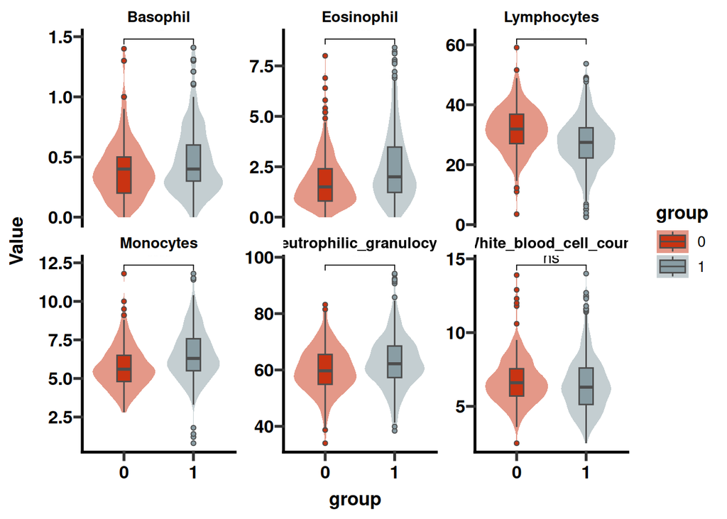

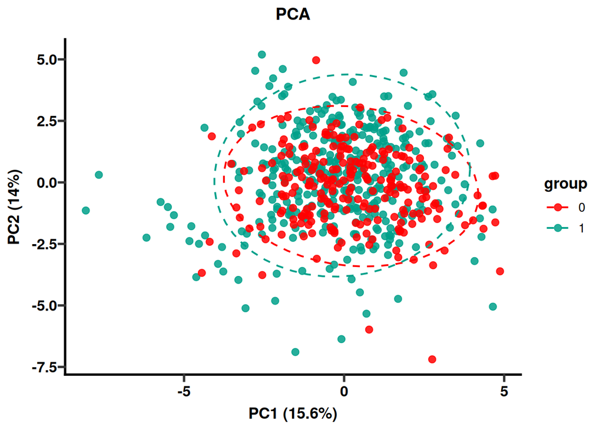

Group-wise distributions and PCA ordination, straight out of `PlotGroupedDistribution()` / `PlotPCA()`. → [Quick-start chapter](https://yulab-smu.top/icare/module1-quickstart.html)

**Module 2 · Classification modeling**

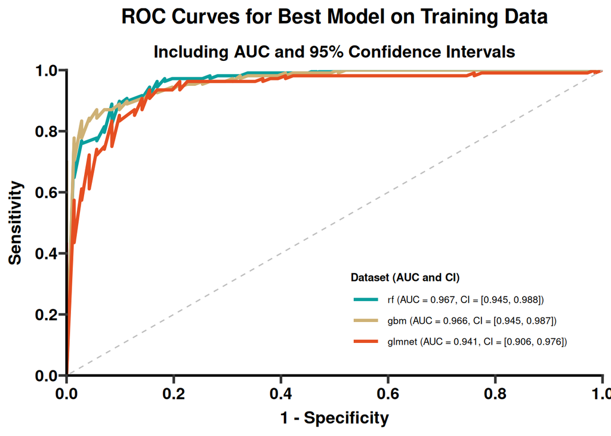

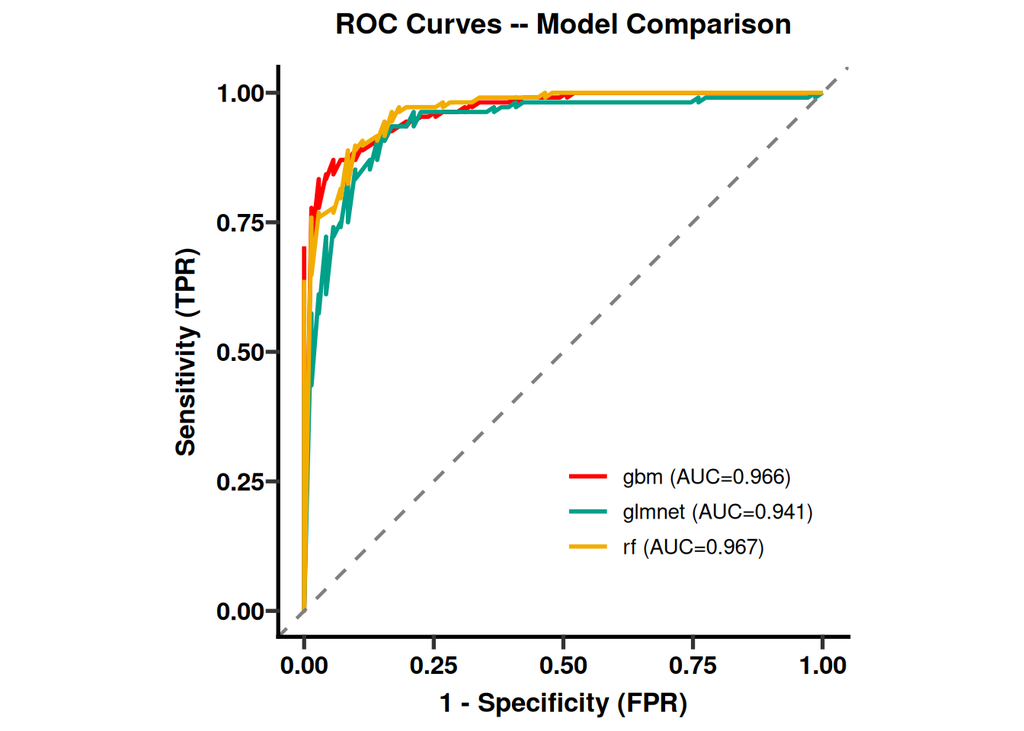

`glmnet` / `rf` / `gbm` benchmarked head-to-head, then the winner’s ROC via `PlotMultiROC()`. → [Quick-start chapter](https://yulab-smu.top/icare/module2-quickstart.html)

**Module 3 · Unsupervised subtyping**

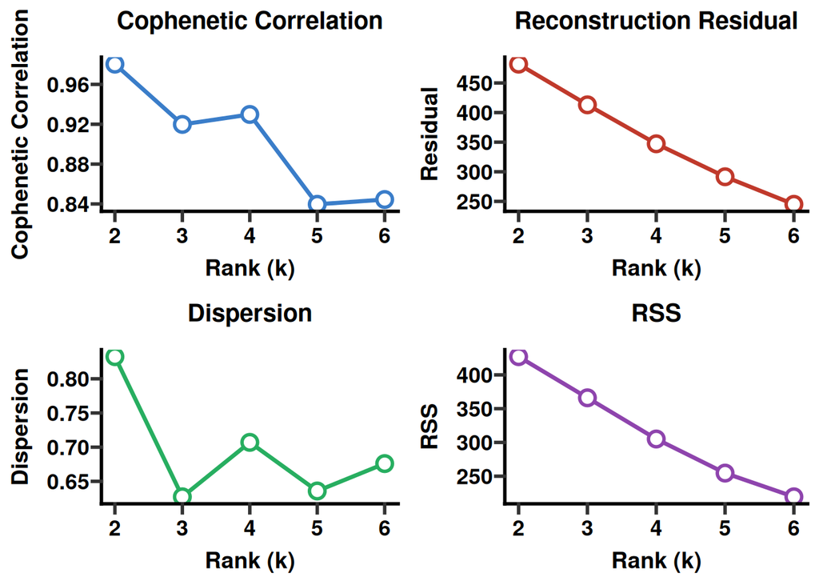

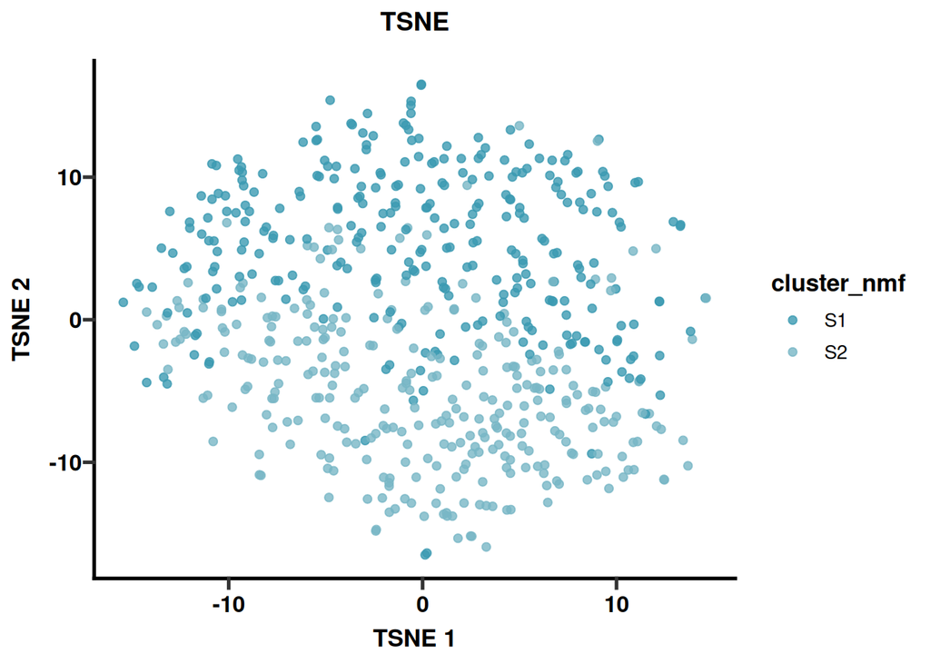

NMF rank estimation and the resulting t-SNE embedding, colored by subtype. → [Quick-start chapter](https://yulab-smu.top/icare/module3-quickstart.html)

**Module 4 · Survival & prognosis**

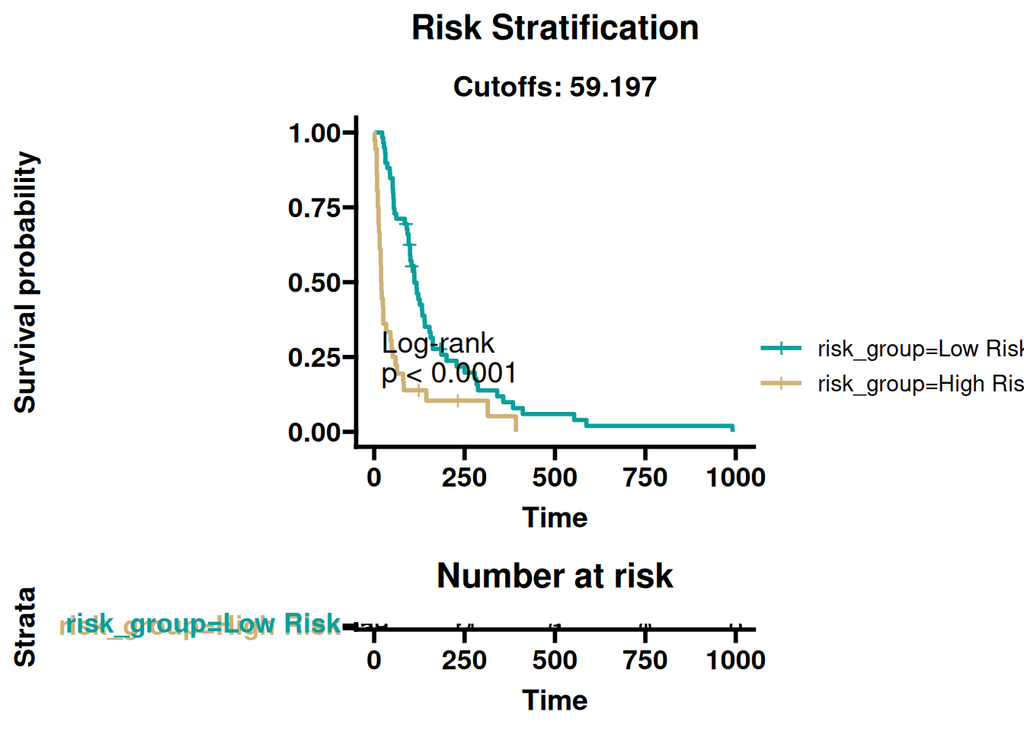

[figure not shown]

👉 Every chapter above (and their **ADVANCED** counterparts) is runnable end-to-end in the [online book](https://yulab-smu.top/icare/) — code, console output, and figures are shown together, chunk by chunk.

## Go further: the ADVANCED gallery

The QUICKSTART chapters get you a result in minutes — the **ADVANCED** chapters are where icare earns its keep for a manuscript: multi-method feature selection with consensus/stability diagnostics, algorithm benchmarking with SHAP/DALEX explanations, three-way clustering validation, and full survival-model robustness/DCA/nomogram workflows. A taste of what each one produces:

**Module 1 · Advanced — publication figures**

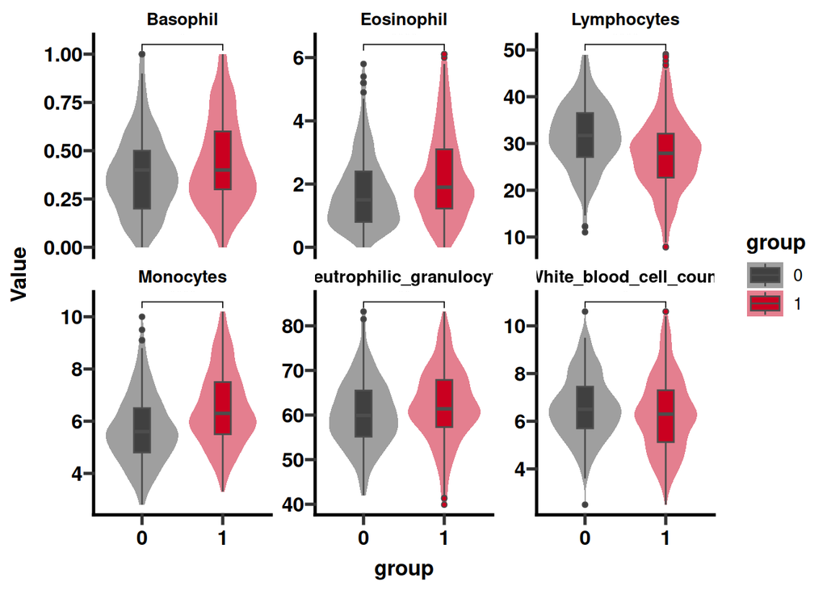

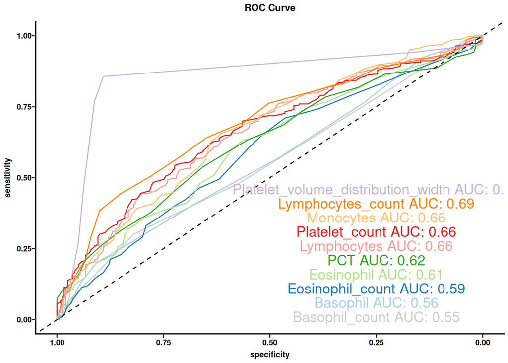

Correlation heatmaps, annotated PCA, AUC/p-value feature triage, radar charts, and a manuscript-ready “Table 1” — all in one script. → [Advanced chapter](https://yulab-smu.top/icare/module1-advanced.html)

**Module 2 · Advanced — benchmarking & explainability**

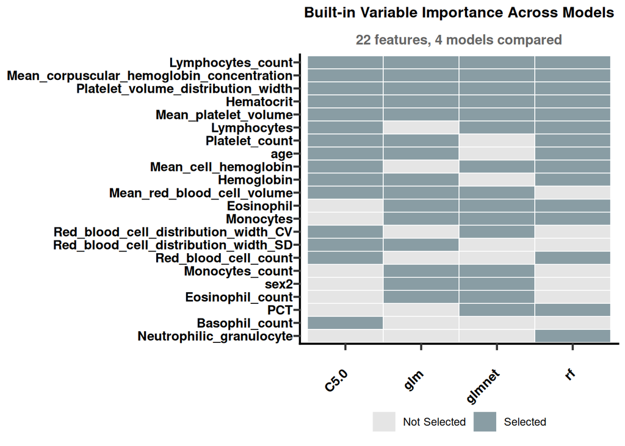

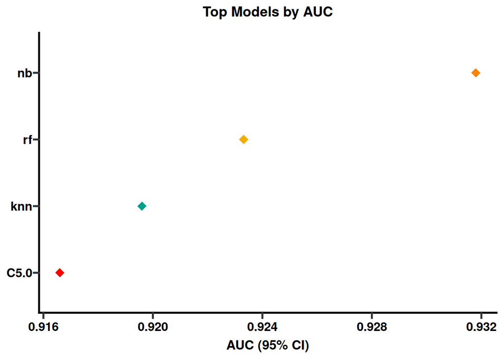

RFE/GA/SA consensus feature selection, a 9-algorithm benchmark, ensembling, Bayesian tuning, and SHAP/DALEX explanations. → [Advanced chapter](https://yulab-smu.top/icare/module2-advanced.html)

**Module 3 · Advanced — three-way clustering validation**

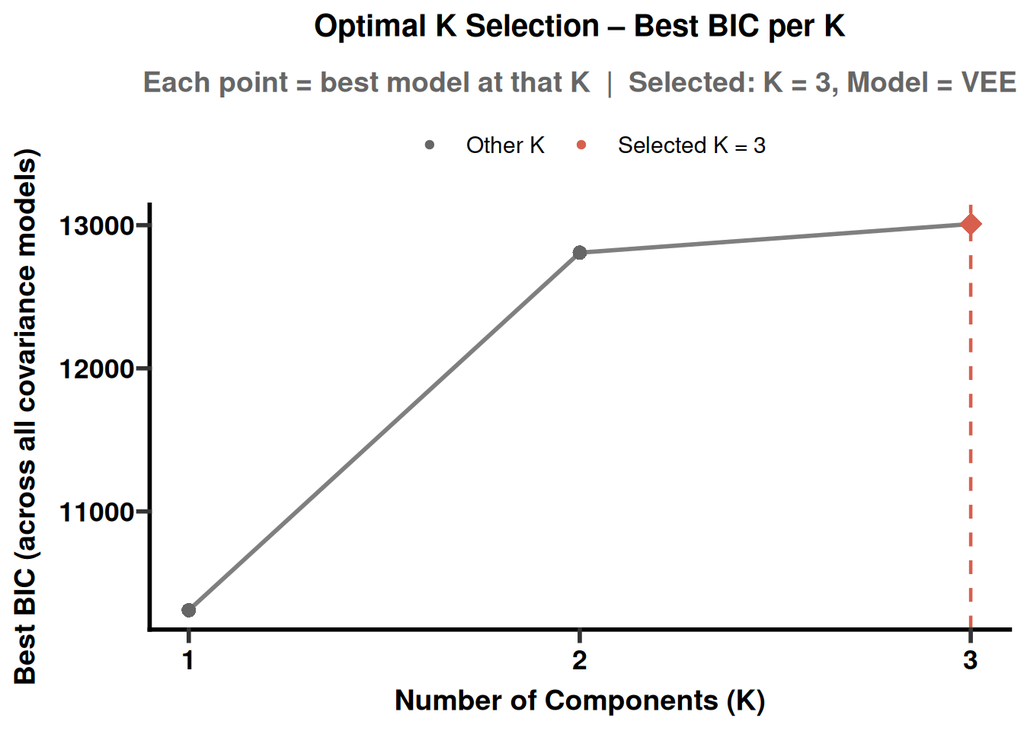

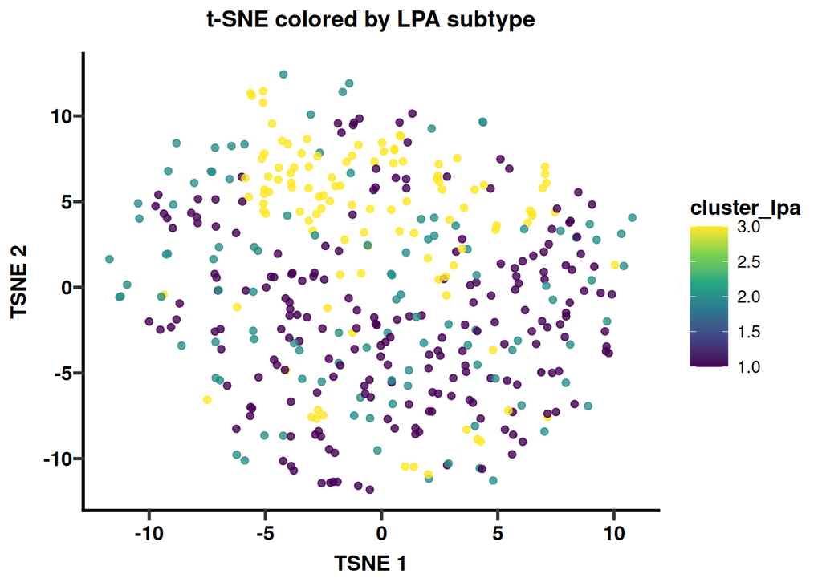

K-means, LPA, and NMF cross-validated against each other (Adjusted Rand Index), with marker heatmaps, silhouettes, and an alluvial agreement diagram. → [Advanced chapter](https://yulab-smu.top/icare/module3-advanced.html)

**Module 4 · Advanced — robust survival modeling**

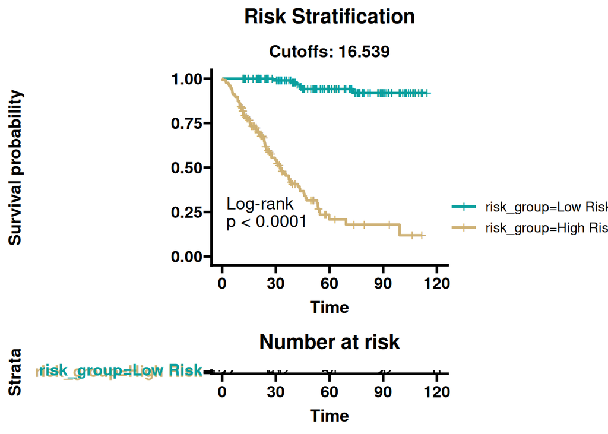

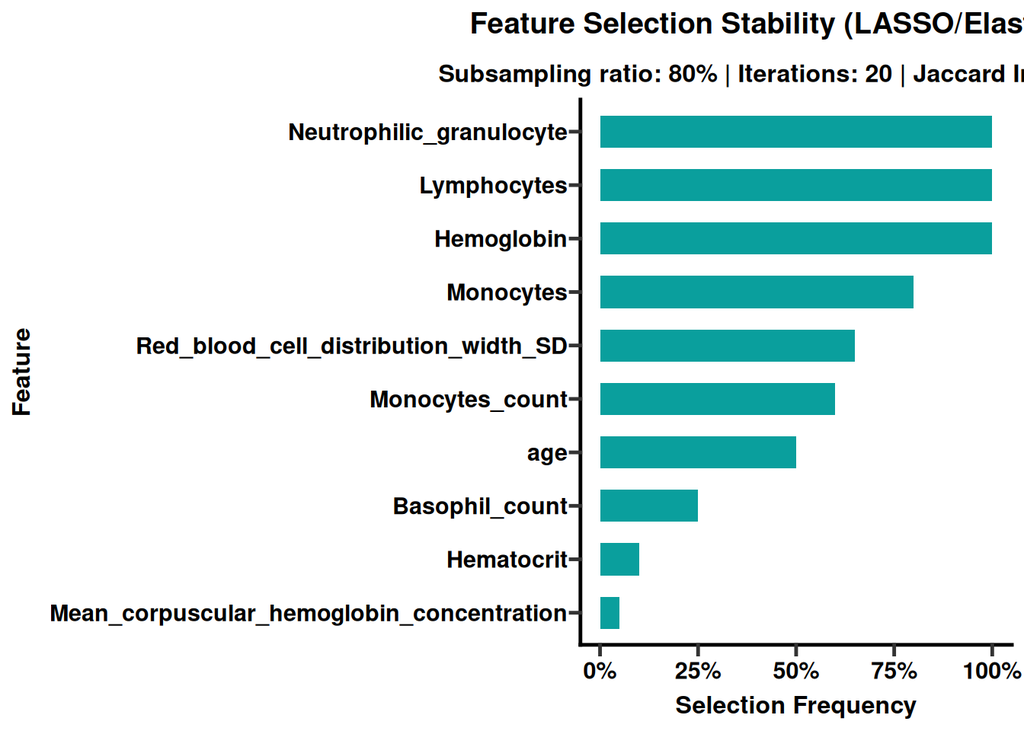

Strict train/validation split, algorithm benchmarking, subgroup forests, time-dependent AUC, calibration, nomograms, stability/ablation checks, DCA, and survival SHAP. → [Advanced chapter](https://yulab-smu.top/icare/module4-advanced.html)

Every advanced script is designed to be run start-to-finish on your own cohort — swap in your data at the top of the `CONFIG` section and the rest of the pipeline (feature selection → modeling/clustering/survival → explainability → export) follows automatically.

## Installation

```r
# install.packages("remotes")
remotes::install_github("YuLab-SMU/icare", dependencies = TRUE)
```

icare depends on a large number of Bioconductor/CRAN packages (`caret`, `mlr3` + `mlr3proba`/`mlr3tuning`, `survival`, `NMF`, `mclust`, `DALEX`, `ComplexHeatmap`, `shiny`, …) — see `DESCRIPTION` for the full list. A plain `remotes::install_github()` will pull in the required CRAN dependencies; Bioconductor packages (e.g. `ComplexHeatmap`) may need to be installed separately first with `BiocManager::install()`.

## The four modules

[output not shown]

Each module ships with a **QUICKSTART** vignette (minimal, sensible defaults) and an **ADVANCED** vignette (every option, publication-style figures) under `vignettes/` — start there for runnable, end-to-end examples on real data. The same chapters are also published as a browsable book at **[yulab-smu.top/icare](https://yulab-smu.top/icare/)**.

## Essential Commands

The tables below are a fast reference for the functions you’ll use most often in each module, grouped the way you’d actually call them in a script. They mirror the shape of a normal icare analysis — see the Quick start section for a compact end-to-end example, and the vignettes for fully worked ones.

### Module 1 — Data cleaning (`Stat`)

```r
# Build the container ---------------------------------------------------
stat_obj <- CreateStatObject(raw.data = mat, info.data = inf,
                              group_col = "group", na.action = "allow")

# Clean it, one step per line -------------------------------------------
stat_obj <- stat_diagnose_variable_type(stat_obj)      # detect numeric vs. categorical
stat_obj <- stat_convert_variables(stat_obj)           # apply those types
stat_obj <- stat_miss_processed(stat_obj, impute_method = "median_mode")  # impute
stat_obj <- stat_detect_and_mark_outliers(stat_obj, method = "iqr")      # flag outliers
stat_obj <- stat_handle_outliers(stat_obj, method = "impute")            # fix them
stat_obj <- stat_onehot_encode(stat_obj)               # encode categoricals
stat_obj <- stat_normalize_process(stat_obj, method = "auto")            # normalize

# Explore & compare groups -----------------------------------------------
PlotGroupedDistribution(stat_obj, features = numeric_vars, group_col = "group")
PlotPCA(stat_obj, color_by = "group", ellipse = TRUE)
stat_obj    <- stat_var_feature(stat_obj, p_threshold = 0.05)   # differential features
deg_result  <- ExtractLastTestSig(stat_obj)
stat_obj    <- stat_gaze_analysis(stat_obj, save_word = TRUE)   # baseline "Table 1"

# Hand off to Module 2 / 3 ------------------------------------------------
saveRDS(stat_obj, "stat_obj.rds")
```

| Command | Purpose |
| --- | --- |
| `CreateStatObject()` | Wrap a raw data matrix + metadata into a `Stat` object |
| `InspectObject()` | Print a structured summary of any icare S4 object |
| `stat_diagnose_variable_type()` / `stat_convert_variables()` | Detect and coerce numeric vs. categorical columns |
| `stat_miss_processed()` | Impute missing values (`"median_mode"`, `"mice"`, `"knn"`, …) |
| `stat_detect_and_mark_outliers()` / `stat_handle_outliers()` | Flag and remediate outliers (IQR, Z-score, …) |
| `stat_onehot_encode()` | One-hot encode categorical variables |
| `stat_normalize_process()` | Normalize numeric variables (`"auto"`, `"z_score"`, `"min_max"`, …) |
| `stat_var_feature()` / `batch_Wilcoxon()` / `ExtractLastTestSig()` | Univariate group-difference testing (differential features) |
| `stat_gaze_analysis()` | Publication-style baseline characteristics table |
| `PlotGroupedDistribution()`, `PlotPCA()` | Quick group-comparison and ordination plots |

### Module 2 — Modeling (`Train_Model`)

```r
# Convert & select features -----------------------------------------------
model_obj <- ConvertObject(stat_obj, to = "Train_Model")
builtin   <- FeatureSelectBuiltin(model_obj, models = c("rf", "glm"), top_n = 15)
model_obj <- ApplyFeatureSelection(model_obj, builtin$importance_table$Feature)

# Split + scale (fit on train, apply to test — no leakage) ----------------
idx <- caret::createDataPartition(model_obj@clean.df[[model_obj@group_col]], p = 0.7, list = FALSE)
model_obj@split.data <- list(training = model_obj@clean.df[idx, ],
                              testing  = model_obj@clean.df[-idx, ])
preProc <- caret::preProcess(model_obj@split.data$training, method = c("center", "scale"))
model_obj@split.scale.data <- list(training = predict(preProc, model_obj@split.data$training),
                                    testing  = predict(preProc, model_obj@split.data$testing))
model_obj@filtered.set <- model_obj@split.scale.data

# Train, compare, ensemble, tune -------------------------------------------
model_obj <- ModelTrainAnalysis(model_obj, methods = c("glmnet", "rf", "gbm"))
model_obj <- SelectBestModel(model_obj, metric = "auc")
model_obj <- TrainEnsemble(model_obj, strategy = "stacking", top_n = 4)
model_obj <- FineTuneModel(model_obj, method = "rf", bounds = BuildTuningBounds(mtry = c(2, 15)))

# Explain & apply clinically -----------------------------------------------
explainer <- CreateExplainer(model_obj)
ExplainSHAPBeeswarm(explainer)
thresh <- CalculateThresholds(model_obj, target_ppv = 0.9)

# Deploy ---------------------------------------------------------------------
deploy_manager <- ModelDeployment(model_obj, preproc = preProc,
                                   class_labels = c("Negative", "Positive"))
deploy_clinlab_app(deploy_manager)
```

| Command | Purpose |
| --- | --- |
| `ConvertObject(x, to = "Train_Model")` | Turn a cleaned `Stat` object into a modeling object |
| `FeatureSelectBuiltin()` / `FeatureSelectionPipeline()` (`ga`/`rfe`/`sa`) / `run_feature_elimination()` | Feature selection: built-in importance, GA/RFE/SA, or performance-elbow elimination |
| `ApplyFeatureSelection()` | Commit to a final feature set |
| `PreprocessingBenchmark()` / `LogisticDiagnosticBenchmark()` | Compare imputation × normalization × algorithm combinations by CV performance |
| `ModelTrainAnalysis()` | Train and cross-validate multiple `caret` algorithms at once |
| `SelectBestModel()` | Pick the top-performing trained model |
| `TrainEnsemble()` | Combine models: `"stacking"`, `"average"`, `"weighted"`, `"voting"` |
| `FineTuneModel()` + `BuildTuningBounds()` / `InspectHyperParams()` | Bayesian hyperparameter search around a chosen algorithm |
| `CreateExplainer()` + `ExplainSHAP*()` / `ExplainVariableImportance()` / `ExplainPartialDependence()` | DALEX/SHAP-based model explainability |
| `CalculateThresholds()` / `ApplyThreshold()` / `ClinicalThreshold()` | PPV/NPV/Youden decision thresholds |
| `ClinicalCorrelation()` / `PlotSubgroupForest()` / `PlotConfounderForest()` | Clinical covariate correlation, subgroup and confounder-adjusted forest plots |
| `CalculateCategoryNRI()` / `PlotIDICurve()` / `NRI_IDI_Analysis()` | Reclassification analysis (NRI/IDI) between two models |
| `PlotMultiROC()`, `PlotConfusionMatrix()`, `PlotCalibration()`, `PlotFeatureImportance()` | Standard performance visualizations |
| `ModelDeployment()` + `deploy_clinlab_app()` | Wrap trained model(s) + preprocessing into a predict function and Shiny app |

### Module 3 — Subtyping (`Subtyping`)

```r
# Convert & normalize (min-max keeps values non-negative, required by NMF) --
sub_obj <- ConvertObject(stat_obj, to = "Subtyping")
sub_obj <- Sub_normalize_process(sub_obj, normalize_method = "min_max", group_col = "group")
sub_obj@scale.data <- remove_constant_columns(sub_obj@scale.data)

# Cluster: NMF (primary; produces a re-usable model) -------------------------
sub_obj <- Sub_nmf_estimate(sub_obj, rank_range = 2:6, nrun = 5, method = "brunet")
sub_obj <- Sub_nmf_best_rank(sub_obj, nrun = 5, method = "brunet")
sub_obj <- Sub_nmf_assign_subtypes(sub_obj)

# ... or K-means / LPA, and cross-compare -------------------------------------
sub_obj <- Sub_kmeans_with_optimal_k(sub_obj, k.max = 8)
sub_obj <- Sub_lpa_with_optimal_k(sub_obj, max_clusters = 3)
compare_clusterings(sub_obj, methods = c("cluster_kmeans", "cluster_lpa", "cluster_nmf"))

# Visualize, validate, find markers --------------------------------------------
sub_obj <- Sub_tsne_analyse(sub_obj, use_scaled_data = TRUE)
PlotDimReduction(sub_obj, reduction = "tsne", color_by = "cluster_nmf")
eval_result <- Sub_evaluation_results(sub_obj)
multi_deg   <- batch_Wilcoxon_MultiClass(mat = deg_df, group_col = "subtype")
PlotClusterHeatmap(sub_obj, deg_df = multi_deg, group_by = "cluster_nmf", top_n = 5)

# Deploy ------------------------------------------------------------------------
sub_manager <- New_Sub_Manager(sub_obj)
launch_sub_deploy_app(sub_manager)
```

| Command | Purpose |
| --- | --- |
| `ConvertObject(x, to = "Subtyping")` | Turn a cleaned `Stat` object into a subtyping object |
| `Sub_normalize_process()` / `Sub_extract_norm_params()` / `Sub_apply_norm_params()` | Fit normalization on training data and replay it on validation/new data |
| `SplitSubtypingObject()` | Stratified train/validation split for cluster validation |
| `Sub_kmeans_with_optimal_k()` | K-means with automatic k selection |
| `Sub_lpa_with_optimal_k()` | Latent profile analysis (Gaussian mixture) |
| `Sub_nmf_estimate()` → `Sub_nmf_best_rank()` → `Sub_nmf_assign_subtypes()` → `Sub_nmf_train_model()` | Non-negative matrix factorization pipeline, including a re-usable model |
| `Sub_predict_subtypes()` | Assign new/validation samples to existing subtypes |
| `Sub_tsne_analyse()` / `Sub_umap_analyse()` + `PlotDimReduction()` | Dimensionality reduction for visualization |
| `Sub_evaluation_results()` | Cluster-quality metrics (silhouette, etc.) |
| `compare_clusterings()` / `plot_clustering_comparison()` | Adjusted Rand Index agreement between methods |
| `batch_Wilcoxon_MultiClass()` + `PlotClusterHeatmap()` / `PlotGroupMeanHeatmap()` | Subtype-specific marker discovery and heatmaps |
| `PlotSilhouette()` / `PlotMultiAlluvial()` | Separation diagnostics and multi-method/outcome alluvial plots |
| `New_Sub_Manager()` + `launch_sub_deploy_app()` | Deploy the trained subtyping model as a Shiny app |

### Module 4 — Survival / Prognosis (`PrognosiX`)

```r
# Convert (moves time/status into info.data, keeps numeric features) --------
stat <- CreateStatObject(raw.data = df, group_col = NULL, na.action = "allow")
prog <- Stat_to_PrognosiX(stat, time_col = "time", status_col = "status", min_events = 10)

# Feature selection: univariate Cox + LASSO -----------------------------------
feat_sel <- surv_feature_selection_multi(prog, methods = c("uni_cox", "lasso"), combine = "union")
prog@survival.var <- list(selected = feat_sel$selected)

# Train/validation split (mlr3 tasks) ------------------------------------------
task <- surv_extract_task(prog)$select(feat_sel$selected)
train_task <- task$clone()$filter(train_idx)
val_task   <- task$clone()$filter(val_idx)

# Benchmark algorithms, then train and tune the winner --------------------------
bmr   <- surv_run_algorithm_benchmark(train_task, learners_list = c("surv.coxph", "surv.ranger"))
learner <- surv_get_learner("surv.ranger", train_task)
learner$train(train_task)
tuned   <- surv_train_and_tune(train_task, "surv.ranger")

# Evaluate, stratify risk, and validate -----------------------------------------
surv_evaluate_model(learner, val_task)
km <- surv_plot_risk_km(learner, train_task, cutoff_method = "median", risk_table = TRUE)
nom <- surv_generate_nomogram(prog, features = feat_sel$selected)   # includes a PH check

# Predict for new patients and deploy ---------------------------------------------
predict_prognosix(prog, new_patients)
predict_risk_groups(prog, new_patients, cutoff_method = "median")
prog_manager <- New_Prog_Manager(prog)
launch_prog_deploy_app(prog_manager)
```

| Command | Purpose |
| --- | --- |
| `Stat_to_PrognosiX()` | Convert a `Stat` object into a survival-modeling (`PrognosiX`) object |
| `surv_feature_selection_multi()` | Univariate Cox / LASSO feature selection (`combine = "union"`/`"intersect"`) |
| `surv_extract_task()` | Build an `mlr3proba::TaskSurv` from a `PrognosiX` object |
| `surv_get_learner()` / `surv_run_algorithm_benchmark()` | Instantiate or cross-validate `mlr3proba` survival learners (Cox, RSF, `surv.ranger`, …) |
| `surv_train_and_tune()` | Hyperparameter tuning of a survival learner |
| `surv_evaluate_model()` | C-index / Brier score / time-dependent AUC evaluation |
| `surv_plot_risk_km()` | Kaplan–Meier risk stratification (`"median"`, `"tertile"`, `"quartile"`, `"p_optimize"`, `"custom"`) |
| `surv_generate_nomogram()` | Cox-based nomogram, with an automatic proportional-hazards (`cox.zph`) check |
| `predict_prognosix()` / `predict_risk_groups()` | Score and risk-classify new patients |
| `run_prognosis_pipeline()` | End-to-end orchestration of the steps above in one call |
| `New_Prog_Manager()` + `launch_prog_deploy_app()` | Deploy the trained survival model as a Shiny app |

> **Methodological note.** Several of the “essential commands” above only report an unbiased estimate of performance when you actually pass a held-out split (`val_task`, `split.data$testing`, …) rather than re-using the data a model was trained/tuned on — e.g. `surv_plot_risk_km()` and `surv_generate_nomogram()` will happily run on the training task, but the resulting p-values/HRs should then be treated as descriptive, not confirmatory. See each function’s documentation for details.

## Quick start

The fastest way to see the whole pipeline end-to-end is the QUICKSTART vignette for each module, in order:

```r
library(icare)

# Module 1: raw data -> cleaned Stat object -> stat_obj.rds
source(system.file("vignettes", "01_module1_data_cleaning_QUICKSTART.R", package = "icare"))

# Module 2: stat_obj.rds -> trained/evaluated Train_Model -> model_obj.rds
source(system.file("vignettes", "02_module2_modeling_QUICKSTART.R", package = "icare"))

# Module 3: stat_obj.rds -> NMF subtypes -> subtyping_obj.rds
source(system.file("vignettes", "03_module3_subtyping_QUICKSTART.R", package = "icare"))

# Module 4: your own time/status data.frame -> survival model + KM/risk groups
source(system.file("vignettes", "04_module4_survival_QUICKSTART.R", package = "icare"))
```

Each QUICKSTART script points to its ADVANCED counterpart for the full option set (multi-method feature selection, ensembling, tuning, SHAP/DALEX explanations, clinical thresholds & NRI/IDI, cluster cross-validation, survival benchmarking, decision-curve analysis, and the Shiny deployment apps). Prefer to read rather than run? The same scripts are rendered with output and figures at **[yulab-smu.top/icare](https://yulab-smu.top/icare/)**.

## Getting help

- Full documentation & worked examples: **[yulab-smu.top/icare](https://yulab-smu.top/icare/)**
- Function-level help: `?FunctionName` inside R, or `InspectObject(x)` to inspect any icare S4 object’s current state.
- Bug reports and feature requests: please open a [GitHub issue](https://github.com/YuLab-SMU/icare/issues) with a minimal reproducible example.

## Citation

```
Luo H, Long F, Lin H, Yuan C, Wang F, Huang J, Yu G. icare: Intelligent
ClinlAbomics Research Expedition. R package version 1.0.1.
```

## License

GPL-3 © Huaichao Luo, Fei Long, Hongyan Lin, Jian Huang, Guangchuang Yu